# Australian taxes are non-egalitarian

Our tax system is deliberately setup to subsidise wealthy investors to further wealth-accumulate at a discount without paying their fair share of taxes.

Checkout the modelling below to understand how this is the case.

```python
import matplotlib.pyplot as plt
```

```python
# CPI assumption for the past X years
CPI=1.02
def au_tax(income, cap_harvest=0, cgt_discount=False, cgt_index=0):
    if cgt_discount:
        val = income + 0.5 * cap_harvest
    else:
        val = income + cap_harvest

    if cgt_index > 0 and cgt_discount == False:
        val = income + (1 -((CPI ** cgt_index) - 1)) * cap_harvest

    if val < 18200:
        return 0
    elif val < 45000:
        val -= 18200
        return 0.19 * val
    elif val < 120000:
        val -= 45000
        return 0.325 * val + 5092
    elif val < 180000:
        val -= 120000
        return 0.37 * val + 29467
    else:
        val -= 180000
        return 0.45 * val + 51667
```

```python
worker_tax = [ au_tax(x) for x in range(0, 1000000, 1000) ]
worker_income = [ x for x in range (0, 1000000, 1000) ]
investor_tax = [ au_tax(0, cap_harvest=x, cgt_discount=True) for x in range (0, 1000000, 1000)]
investor_income = [ x for x in range (0, 1000000, 1000) ]
```

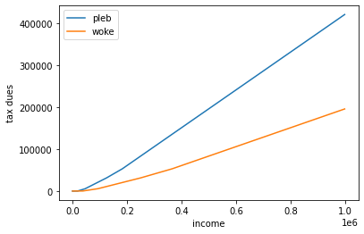

```python
line1, = plt.plot(worker_income, worker_tax)
line2, = plt.plot(investor_income, investor_tax)
line1.set_label('pleb')
line2.set_label('woke')
plt.legend()
plt.ylabel('tax dues')
_ = plt.xlabel('income')
```

```python
worker_effective = [ au_tax(x)/x for x in range(1, 1000000, 1000) ]
investor_effective = [ au_tax(0, cap_harvest=x, cgt_discount=True)/x for x in range (1, 1000000, 1000)]
```

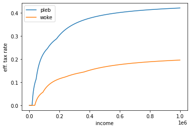

```python
line1, = plt.plot(worker_income, worker_effective)
line2, = plt.plot(investor_income, investor_effective)
line1.set_label('pleb')
line2.set_label('woke')
plt.legend()
plt.ylabel('eff. tax rate')
_ = plt.xlabel('income')
```

As you can see above, if you are a 'pleb', you'd be paying substantially more in taxes compared to your wealth mate who is generating income from capital gains.

A ballpark figure, 300K annual income from purely capital gains proceedonly pays approx 15% in taxes. Just **15%**. While our friend who works 9-5 has to pay a whopping **35%** in effective tax rates instead.

Where is the justice in this!?

## With Fairer CGT Indexation Rule

```python
worker_tax = [ au_tax(x) for x in range(0, 1000000, 1000) ]
worker_income = [ x for x in range (0, 1000000, 1000) ]
investor_tax = [ au_tax(0, cap_harvest=x, cgt_discount=False, cgt_index=5) for x in range (0, 1000000, 1000)]
investor_income = [ x for x in range (0, 1000000, 1000) ]
```

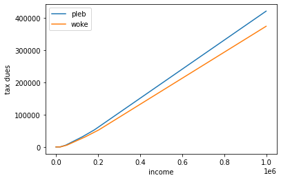

```python
# 5Y Cap Gains
line1, = plt.plot(worker_income, worker_tax)
line2, = plt.plot(investor_income, investor_tax)
line1.set_label('pleb')
line2.set_label('woke')
plt.legend()
plt.ylabel('tax dues')
_ = plt.xlabel('income')
```

The Australian tax system used to only allow tax deductions against capital gains based on CPI indexation so real-terms capital gains do not get eroded by inflation.

Supposedly, these rules still apply today, you will see that our 'woke' friend would be paying similar amount of taxes to our 'pleb' friends.

```python
# 20Y Cap Gains
worker_tax = [ au_tax(x) for x in range(0, 1000000, 1000) ]
worker_income = [ x for x in range (0, 1000000, 1000) ]
investor_tax = [ au_tax(0, cap_harvest=x, cgt_discount=False, cgt_index=20) for x in range (0, 1000000, 1000)]
investor_income = [ x for x in range (0, 1000000, 1000) ]
```

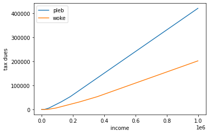

```python
line1, = plt.plot(worker_income, worker_tax)
line2, = plt.plot(investor_income, investor_tax)
line1.set_label('pleb')
line2.set_label('woke')
plt.legend()
plt.ylabel('tax dues')
_ = plt.xlabel('income')
```

Supposedly after 20 years, where inflation really starts to kick in, you see substantial discounts in tax dues for capital gains to mitigate the inflation erosion effects on real terms capital gains.

**Australia should abolish the 50% CGT Discount**